# Treasure Hunt Game Notebook

## Read and Review Your Starter Code

The theme of this project is a popular treasure hunt game in which the player needs to find the treasure before the pirate does. While you will not be developing the entire game, you will write the part of the game that represents the intelligent agent, which is a pirate in this case. The pirate will try to find the optimal path to the treasure using deep Q-learning.

**To Begin:** Use this **TreasureHuntGame_starterCode.ipynb** file to complete your assignment.  
You have been provided with two Python classes and this notebook to help you with this assignment. The first class, **TreasureMaze.py**, represents the environment, which includes a maze object defined as a matrix. The second class, **GameExperience.py**, stores the episodes – that is, all the states that come in between the initial state and the terminal state. This is later used by the agent for learning by experience, called "exploration". This notebook shows how to play a game. Your task is to complete the deep Q-learning implementation in the qtrain() function for which a skeleton implementation has been provided.

**NOTE:** The code block you will need to complete will have **#TODO** as a header.  
First, read and review the next few code and instruction blocks to understand the code that you have been given.

**Installations** The following command will install the necessary Python libraries to necessary to run this application. If you see a "[notice] A new release of pip is available: 23.1.2 -> 25.2" at the end of the installation, you may disregard that statement.

```python
!pip install -r requirements.txt
import os
os.environ["CUDA_VISIBLE_DEVICES"] = "-1"
```

## Tensorflow CPU Acceleration Warning

**GPU/CUDA/Memory Warnings/Errors:** You may receive some errors referencing that GPUs will not be used, CUDA could not be found, or free system memory allocation errors. These and a few others, are standard errors that can be ignored here as they are environment based.  
**Example messages:**

- oneDNN custom operations are on. You may see slightly different numerical results due to floating-point round-off errors from different computation orders
- WARNING: All log messages before absl::InitializeLog() is called are written to STDERR

```python
from __future__ import print_function
import os, sys, time, datetime, json, random
import numpy as np
import tensorflow as tf
from tensorflow.keras.models import clone_model
from keras.models import Sequential
from keras.layers import Dense, Activation, PReLU
from keras.optimizers import SGD , Adam, RMSprop
import matplotlib.pyplot as plt
from TreasureMaze import TreasureMaze
from GameExperience import GameExperience
%matplotlib inline
```

## Maze Object Generation

**NOTE:** The following code block contains an 8x8 matrix that will be used as a maze object:

```python
maze = np.array([
    [ 1.,  0.,  1.,  1.,  1.,  1.,  1.,  1.],
    [ 1.,  0.,  1.,  1.,  1.,  0.,  1.,  1.],
    [ 1.,  1.,  1.,  1.,  0.,  1.,  0.,  1.],
    [ 1.,  1.,  1.,  0.,  1.,  1.,  1.,  1.],
    [ 1.,  1.,  0.,  1.,  1.,  1.,  1.,  1.],
    [ 1.,  1.,  1.,  0.,  1.,  0.,  0.,  0.],
    [ 1.,  1.,  1.,  0.,  1.,  1.,  1.,  1.],
    [ 1.,  1.,  1.,  1.,  0.,  1.,  1.,  1.]
])
```

## Helper Functions and Global Variables

This **show()** helper function allows a visual representation of the maze object:

```python
def show(qmaze):
    plt.grid('on')
    nrows, ncols = qmaze.maze.shape
    ax = plt.gca()
    ax.set_xticks(np.arange(0.5, nrows, 1))
    ax.set_yticks(np.arange(0.5, ncols, 1))
    ax.set_xticklabels([])
    ax.set_yticklabels([])
    canvas = np.copy(qmaze.maze)
    for row,col in qmaze.visited:
        canvas[row,col] = 0.6
    pirate_row, pirate_col, _ = qmaze.state
    canvas[pirate_row, pirate_col] = 0.3   # pirate cell
    canvas[nrows-1, ncols-1] = 0.9 # treasure cell
    img = plt.imshow(canvas, interpolation='none', cmap='gray')
    return img
```

The **pirate agent** can move in four directions: left, right, up, and down.

**Note:** While the agent primarily learns by experience through exploitation, often, the agent can choose to explore the environment to find previously undiscovered paths. This is called "exploration" and is defined by epsilon. This value is the **EXPLORATION** values from the Cartpole assignment. The hyperparameters are provided here and used in the **qtrain()** method. You are encouraged to try various values for the exploration factor and see how the algorithm performs.

```python
LEFT = 0
UP = 1
RIGHT = 2
DOWN = 3


# Exploration factor
epsilon = 1.0
epsilon_min = 0.05
epsilon_decay = 0.99
patience = 10

# Actions dictionary
actions_dict = {
    LEFT: 'left',
    UP: 'up',
    RIGHT: 'right',
    DOWN: 'down',
}

num_actions = len(actions_dict)
```

The sample code block and output below show creating a maze object and performing one action (DOWN), which returns the reward. The resulting updated environment is visualized.

```
reward= -0.04
```

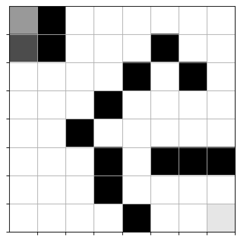

```python
qmaze = TreasureMaze(maze)
canvas, reward, game_over = qmaze.act(DOWN)
print("reward=", reward)
show(qmaze)
```

**NOTE:** This **play_game()** function simulates a full game based on the provided trained model. The other parameters include the TreasureMaze object, the starting position of the pirate and max amount of steps to make sure the code does not get stuck in a loop.

```python
def play_game(model, qmaze, pirate_cell, max_steps=None):
    qmaze.reset(pirate_cell)
    envstate = qmaze.observe()
    steps = 0
    if max_steps is None:
        max_steps = qmaze.maze.size * 4  # safety cutoff

    while steps < max_steps:
        # Check valid actions
        valid_actions = qmaze.valid_actions()
        if not valid_actions:
            return False # Trapped

        state = np.asarray(envstate, dtype=np.float32)
        if state.ndim == 1:
            state = np.expand_dims(state, axis=0)

        q_values = model(state, training=False).numpy()[0]

        #Force the agent to pick the highest Q-value out of only the valid actions
        action = max(valid_actions, key=lambda a: q_values[a])

        envstate, reward, game_status = qmaze.act(action)
        steps += 1

        if game_status == 'win':
            return True
        elif game_status == 'lose':
            return False

    return False  # timed out with no result
```

**Note:** This **completion_check()** function helps you to determine whether the pirate can win any game at all. If your maze is not well designed, the pirate may not win any game at all. In this case, your training would not yield any result. The provided maze in this notebook ensures that there is a path to win and you can run this method to check.

```python
def completion_check(model, maze_or_qmaze, max_steps=None):
    # Accept either raw numpy maze or TreasureMaze instance
    if isinstance(maze_or_qmaze, TreasureMaze):
        qmaze = maze_or_qmaze
    else:
        qmaze = TreasureMaze(maze_or_qmaze)

    for cell in qmaze.free_cells:
        if not qmaze.valid_actions(cell):
            continue
        if not play_game(model, qmaze, cell, max_steps=max_steps):
            print("Failed starting cell:", cell)
            return False
    return True
```

**Note:** The **build_model()** function in the block below will build the neural network model. Review the code and note the number of layers, as well as the activation, optimizer, and loss functions that are used to train the model.

```python
def build_model(maze):
    model = Sequential()
    model.add(Dense(128, input_shape=(maze.size,)))
    model.add(PReLU())
    model.add(Dense(128))
    model.add(PReLU())
    model.add(Dense(num_actions))
    model.compile(optimizer='adam', loss='mse')
    return model
```

If you're interested in reading up on the *@tf.function*, which is a decorator for Tensorflow to run this code into a TensorFlow computation graph, please refer to this link: https://www.tensorflow.org/guide/intro_to_graphs

## Tensorflow GPU Warning

You will see a **warning in red** "INTERNAL: CUDA Runtime error: Failed call to cudaGetRuntimeVersion: Error loading CUDA libraries. GPU will not be used.". This is simply coming from **Tensorflow skipping using GPU for this assignment.**

```python
loss_fn = tf.keras.losses.MeanSquaredError()
optimizer = tf.keras.optimizers.Adam()
```

# #TODO: Complete the Q-Training Algorithm Code Block

This is your deep Q-learning implementation. The goal of your deep Q-learning implementation is to find the best possible navigation sequence that results in reaching the treasure cell while maximizing the reward. In your implementation, you need to determine the optimal number of epochs to achieve a 100% win rate.

**Pseudocode:**  
For each epoch: Reset the environment at a random starting cell agent_cell = randomly select a free cell  
**Hint:** Review the reset method in the TreasureMaze.py class.

```
    Set the initial environment state
    env_state should reference the environment's current state
    Hint: Review the observe method in the TreasureMaze.py class.

    While game status is not game over:
       previous_envstate = env_state
        Decide on an action:
            - If possible, take a random valid exploration action and
              randomly choose action (left, right, up, down)
              and assign it to an action variable
            - Else, pick the best exploitation action from the model and assign it to an action variable
              Hint: Review the predict method in the GameExperience.py class.

       Retrieve the values below from the act() method.
       env_state, reward, game_status = qmaze.act(action)
       Hint: Review the act method in the TreasureMaze.py class.

        Track the wins and losses from the game_status using win_history

       Store the episode below in the Experience replay object
       episode = [previous_envstate, action, reward, envstate, game_status]
       Hint: Review the remember method in the GameExperience.py class.

       Train neural network model and evaluate loss
       Hint: Call GameExperience.get_data to retrieve training data (input and target)
       and pass to the train_step method and assign it to batch_loss and append to the loss variable

  If the win rate is above the threshold and your model passes the completion check, that would be your epoch.
```

Note: A 100% win rate **DOES NOT EXPLICITLY MEAN** that you have solved the maze. It simply indicates that during the last evaluation, the pirate *happened* to get to the treasure. Be sure to utilise the **completion_check()** function to validate your pirate found the treasure at every starting point and consistently!

**You will need to complete the section starting with #START_HERE. Please use the pseudocode above as guidance.**

```python
def qtrain(model, maze, **opt):
    #Train the pirate in 3 stages
    #1. Generate a successful path with breadth first search (BFS)
    #2. Warm up the neural network on those paths
    #3. fine tune the policy with Deep Q

    global epsilon

    loss_history = []
    win_rate_history = []
    epsilon_history = []
    reward_history = []

    n_epoch = opt.get("n_epoch", 2000)
    max_memory = opt.get("max_memory", 5000)
    data_size = opt.get("data_size", 64)

    start_time = datetime.datetime.now()
    qmaze = TreasureMaze(maze)

    target_model = tf.keras.models.clone_model(model)
    target_model.set_weights(model.get_weights())

    experience = GameExperience(model, target_model, max_memory=max_memory)

    hsize = 100
    win_history = []

    epsilon = opt.get("epsilon", 0.10)
    epsilon_decay = opt.get("epsilon_decay", 0.995)
    epsilon_min = opt.get("epsilon_min", 0.02)

    #This is a BFS helper
    #Purpose is to generate guaranteed valid paths to the treasure,
    #as pure random exploration was not reliable at all in this maze
    def shortest_path_actions(start):
        target = (maze.shape[0] - 1, maze.shape[1] - 1)

        moves = {
            LEFT:  (0, -1),
            UP:    (-1, 0),
            RIGHT: (0, 1),
            DOWN:  (1, 0)
        }

        queue = [(start, [])]
        visited = {start}

        while queue:
            cell, path = queue.pop(0)

            if cell == target:
                return path

            r, c = cell

            for action, (dr, dc) in moves.items():
                nr, nc = r + dr, c + dc
                nxt = (nr, nc)

                if nr < 0 or nr >= maze.shape[0]:
                    continue
                if nc < 0 or nc >= maze.shape[1]:
                    continue
                if maze[nr, nc] == 0.0:
                    continue
                if nxt in visited:
                    continue

                visited.add(nxt)
                queue.append((nxt, path + [action]))

        return None

    #This is the warm up/warm starting data
    #Builds surpervised training examples from the successful paths
    #Learns what good actions look like before training starts and reinforcement begins
    print("Building warm-start training data...")

    X = []
    y = []

    all_start_cells = list(qmaze.free_cells)

    for start_cell in all_start_cells:
        path = shortest_path_actions(start_cell)

        if path is None:
            continue

        qmaze.reset(start_cell)
        envstate = qmaze.observe()

        for action in path:
            #corrrect action from shortest path is given highest target value,
            #while other actions are pushed lower to teach perferred move
            target_q = np.zeros(num_actions, dtype=np.float32)
            target_q[:] = -1.0
            target_q[action] = 1.0

            X.append(envstate[0])
            y.append(target_q)

            prev_envstate = envstate
            envstate, reward, game_status = qmaze.act(action)

            experience.remember([
                prev_envstate,
                action,
                reward,
                envstate,
                game_status != "not_over"
            ])

            if game_status == "win":
                break

    X = np.array(X, dtype=np.float32)
    y = np.array(y, dtype=np.float32)

    print("Warm-start samples:", len(X))

    #Pretraining like this gives a strong initial policy instead of demanding it
    #discovers the maze through trial and error, which was not working
    print("Training model on known successful paths...")

    for i in range(300):
        h = model.fit(X, y, epochs=1, batch_size=32, verbose=0)

        if i % 50 == 0:
            print(f"Warm-start epoch {i}/300 | Loss={h.history['loss'][0]:.4f}")

    target_model.set_weights(model.get_weights())

    print("Checking model after warm-start...")
    warm_start_passed = completion_check(model, qmaze)

    if warm_start_passed:
        print("Warm-start produced a working initial policy.")
    else:
        print("Warm-start did not fully solve the maze, continuing with DQN fine-tuning...")

    print("Continuing with DQN fine-tuning to validate and stabilize the learned policy...")

    #Now begins the reinforcement training and Deep Q
    dqn_start_index = len(win_history)
    for epoch in range(n_epoch):

        if epoch % 4 == 0:
            start_cell = (0, 0)
        else:
            start_cell = random.choice(qmaze.free_cells)

        qmaze.reset(start_cell)
        envstate = qmaze.observe()

        game_over = False
        steps = 0
        max_steps = maze.size * 4
        loss = 0

        #Below is epsilon greedy, which balances exploration and exploitation,
        #Random actions can help discover new paths, while greedy actions used learned Q values
        while not game_over and steps < max_steps:
            valid_actions = qmaze.valid_actions()

            if np.random.rand() < epsilon:
                action = random.choice(valid_actions)
            else:
                q = model.predict(envstate, verbose=0)[0]
                action = max(valid_actions, key=lambda a: q[a])

            prev_envstate = envstate
            envstate, reward, game_status = qmaze.act(action)

            #remember actions from batch of past experiences
            experience.remember([
                prev_envstate,
                action,
                reward,
                envstate,
                game_status != "not_over"
            ])

            steps += 1

            if game_status == "win":
                win_history.append(1)
                game_over = True

            elif game_status == "lose":
                win_history.append(0)
                game_over = True

        if not game_over:
            win_history.append(0)

        if len(experience.memory) >= data_size:
            inputs, targets = experience.get_data(data_size)
            h = model.fit(inputs, targets, epochs=1, verbose=0)
            loss = h.history["loss"][0]

        #update target network to stabilize q learning targets and reduce oscillation
        if epoch % 25 == 0:
            target_model.set_weights(model.get_weights())

        #moving win rate window allows me to measure recent performance instead of averaging
        #over the entire history, uses however many epochs so far, to allow smooth curve
        window = min(len(win_history), hsize)
        win_rate = sum(win_history[-window:]) / window if window > 0 else 0

        epsilon = max(epsilon * epsilon_decay, epsilon_min)

        dt = datetime.datetime.now() - start_time
        t = format_time(dt.total_seconds())

        print(
            "Epoch: {:03d}/{:d} | Loss: {:.4f} | Episodes: {:d} | Win count: {:d} | Win rate: {:.3f} | Epsilon: {:.3f} | time: {}".format(
                epoch,
                n_epoch - 1,
                loss,
                epoch + 1,
                sum(win_history),
                win_rate,
                epsilon,
                t
            )
        )

        loss_history.append(loss)
        win_rate_history.append(win_rate)
        epsilon_history.append(epsilon)
        reward_history.append(qmaze.total_reward)

        #finally, completion check, verifies the policy can solve the maze from every
        #starting position, then ends model
        if epoch % 100 == 0 and epoch >= 300:
            print("Checking completion after DQN fine-tuning...")
            if completion_check(model, qmaze):
                print("Success: Maze fully solved after DQN fine-tuning at epoch", epoch)
                break

    total_time = format_time((datetime.datetime.now() - start_time).total_seconds())

    #for graphing purposes
    dqn_win_history = win_history[dqn_start_index:]

    dqn_win_rate_history = []
    for i in range(len(dqn_win_history)):
        start = max(0, i - hsize + 1)
        window = dqn_win_history[start:i+1]
        dqn_win_rate_history.append(sum(window) / len(window))


    #Below are graphs to analyze progress throughout policy journey
    print("Training complete in:", total_time)
    print("\nTraining Summary")
    print("------------------")
    print(f"Epochs completed: {epoch + 1}")
    print(f"Final win rate: {win_rate:.3f}")
    print(f"Final epsilon: {epsilon:.3f}")
    print(f"Total wins: {sum(win_history)}")
    print(f"Training time: {total_time}")

    #Win rate once DQN started
    plt.figure(figsize=(10,5))
    plt.plot(dqn_win_rate_history)
    plt.title("DQN Fine-Tuning Win Rate")
    plt.xlabel("DQN Epoch")
    plt.ylabel("Win Rate")
    plt.ylim(0, 1.05)
    plt.show()

    #training loss
    plt.figure(figsize=(10,5))
    plt.plot(loss_history)
    plt.title("Training Loss")
    plt.xlabel("Epoch")
    plt.ylabel("Loss")
    plt.show()

    #epsilon/exploration
    plt.figure(figsize=(10,5))
    plt.plot(epsilon_history)
    plt.title("Exploration Rate")
    plt.xlabel("Epoch")
    plt.ylabel("Epsilon")
    plt.show()

    #success per episode
    plt.figure(figsize=(10,5))
    plt.plot(dqn_win_history)
    plt.title("DQN Episode Outcomes")
    plt.xlabel("DQN Epoch")
    plt.ylabel("Outcome (1 = win, 0 = loss)")
    plt.ylim(-0.05, 1.05)
    plt.show()

    return model


# This is a small utility for printing readable time strings:
def format_time(seconds):
    if seconds < 400:
        s = float(seconds)
        return "%.1f seconds" % (s,)
    elif seconds < 4000:
        m = seconds / 60.0
        return "%.2f minutes" % (m,)
    else:
        h = seconds / 3600.0
        return "%.2f hours" % (h,)
```

## Test Your Model

Now we will start testing the deep Q-learning implementation. To begin, select **Cell**, then **Run All** from the menu bar. This will run your notebook. As it runs, you should see output begin to appear beneath the next few cells. The code below creates an **instance** of TreasureMaze. This does not show your actual training done.

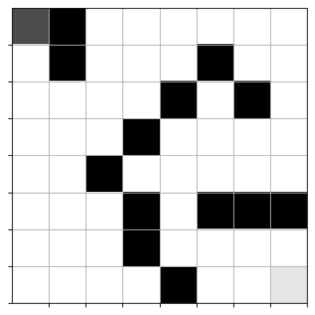

```python
qmaze = TreasureMaze(maze)
show(qmaze)
```

In the next code block, you will build your model using the **build_model** function and train it using deep Q-learning. Note: This step takes several minutes to fully run.

**WARNING** If you did not attempt the assignment, the code **will** error out at this section.

[output not shown]

```
Building warm-start training data...
Warm-start samples: 782
Training model on known successful paths...
Warm-start epoch 0/300 | Loss=0.7080
Warm-start epoch 50/300 | Loss=0.0303
Warm-start epoch 100/300 | Loss=0.0156
Warm-start epoch 150/300 | Loss=0.0014
Warm-start epoch 200/300 | Loss=0.0001
Warm-start epoch 250/300 | Loss=0.0383
Checking model after warm-start...
Warm-start produced a working initial policy.
Continuing with DQN fine-tuning to validate and stabilize the learned policy...
Epoch: 000/1999 | Loss: 0.0128 | Episodes: 1 | Win count: 1 | Win rate: 1.000 | Epsilon: 0.100 | time: 30.3 seconds
Epoch: 001/1999 | Loss: 0.0115 | Episodes: 2 | Win count: 2 | Win rate: 1.000 | Epsilon: 0.099 | time: 30.4 seconds
Epoch: 002/1999 | Loss: 0.0056 | Episodes: 3 | Win count: 3 | Win rate: 1.000 | Epsilon: 0.099 | time: 31.2 seconds
Epoch: 003/1999 | Loss: 0.0028 | Episodes: 4 | Win count: 4 | Win rate: 1.000 | Epsilon: 0.098 | time: 32.1 seconds
Epoch: 004/1999 | Loss: 0.0023 | Episodes: 5 | Win count: 5 | Win rate: 1.000 | Epsilon: 0.098 | time: 33.2 seconds
Epoch: 005/1999 | Loss: 0.0026 | Episodes: 6 | Win count: 6 | Win rate: 1.000 | Epsilon: 0.097 | time: 33.4 seconds
Epoch: 006/1999 | Loss: 0.0055 | Episodes: 7 | Win count: 7 | Win rate: 1.000 | Epsilon: 0.097 | time: 33.9 seconds
Epoch: 007/1999 | Loss: 0.0027 | Episodes: 8 | Win count: 8 | Win rate: 1.000 | Epsilon: 0.096 | time: 34.1 seconds
Epoch: 008/1999 | Loss: 0.0022 | Episodes: 9 | Win count: 9 | Win rate: 1.000 | Epsilon: 0.096 | time: 35.2 seconds
Epoch: 009/1999 | Loss: 0.0032 | Episodes: 10 | Win count: 10 | Win rate: 1.000 | Epsilon: 0.095 | time: 36.5 seconds
Epoch: 010/1999 | Loss: 0.0133 | Episodes: 11 | Win count: 11 | Win rate: 1.000 | Epsilon: 0.095 | time: 37.4 seconds
Epoch: 011/1999 | Loss: 0.0017 | Episodes: 12 | Win count: 12 | Win rate: 1.000 | Epsilon: 0.094 | time: 37.9 seconds
Epoch: 012/1999 | Loss: 0.0121 | Episodes: 13 | Win count: 13 | Win rate: 1.000 | Epsilon: 0.094 | time: 39.3 seconds
Epoch: 013/1999 | Loss: 0.0014 | Episodes: 14 | Win count: 14 | Win rate: 1.000 | Epsilon: 0.093 | time: 40.5 seconds
Epoch: 014/1999 | Loss: 0.0023 | Episodes: 15 | Win count: 15 | Win rate: 1.000 | Epsilon: 0.093 | time: 40.9 seconds
Epoch: 015/1999 | Loss: 0.0026 | Episodes: 16 | Win count: 16 | Win rate: 1.000 | Epsilon: 0.092 | time: 41.6 seconds
Epoch: 016/1999 | Loss: 0.0273 | Episodes: 17 | Win count: 17 | Win rate: 1.000 | Epsilon: 0.092 | time: 42.8 seconds
Epoch: 017/1999 | Loss: 0.0153 | Episodes: 18 | Win count: 18 | Win rate: 1.000 | Epsilon: 0.091 | time: 43.7 seconds
Epoch: 018/1999 | Loss: 0.0363 | Episodes: 19 | Win count: 19 | Win rate: 1.000 | Epsilon: 0.091 | time: 43.9 seconds
Epoch: 019/1999 | Loss: 0.0247 | Episodes: 20 | Win count: 20 | Win rate: 1.000 | Epsilon: 0.090 | time: 44.4 seconds
Epoch: 020/1999 | Loss: 0.0121 | Episodes: 21 | Win count: 21 | Win rate: 1.000 | Epsilon: 0.090 | time: 45.6 seconds
Epoch: 021/1999 | Loss: 0.0130 | Episodes: 22 | Win count: 22 | Win rate: 1.000 | Epsilon: 0.090 | time: 46.0 seconds
Epoch: 022/1999 | Loss: 0.0128 | Episodes: 23 | Win count: 23 | Win rate: 1.000 | Epsilon: 0.089 | time: 46.3 seconds
Epoch: 023/1999 | Loss: 0.0120 | Episodes: 24 | Win count: 24 | Win rate: 1.000 | Epsilon: 0.089 | time: 47.2 seconds
Epoch: 024/1999 | Loss: 0.0104 | Episodes: 25 | Win count: 25 | Win rate: 1.000 | Epsilon: 0.088 | time: 48.3 seconds
Epoch: 025/1999 | Loss: 0.0189 | Episodes: 26 | Win count: 26 | Win rate: 1.000 | Epsilon: 0.088 | time: 49.2 seconds
Epoch: 026/1999 | Loss: 0.0038 | Episodes: 27 | Win count: 27 | Win rate: 1.000 | Epsilon: 0.087 | time: 50.3 seconds
Epoch: 027/1999 | Loss: 0.0022 | Episodes: 28 | Win count: 28 | Win rate: 1.000 | Epsilon: 0.087 | time: 51.3 seconds
```

[output cut: 269 more lines]

```
Epoch: 297/1999 | Loss: 0.0021 | Episodes: 298 | Win count: 292 | Win rate: 0.980 | Epsilon: 0.022 | time: 359.0 seconds
Epoch: 298/1999 | Loss: 0.0016 | Episodes: 299 | Win count: 293 | Win rate: 0.980 | Epsilon: 0.022 | time: 359.5 seconds
Epoch: 299/1999 | Loss: 0.0016 | Episodes: 300 | Win count: 294 | Win rate: 0.980 | Epsilon: 0.022 | time: 360.8 seconds
Epoch: 300/1999 | Loss: 0.0026 | Episodes: 301 | Win count: 295 | Win rate: 0.980 | Epsilon: 0.022 | time: 362.1 seconds
Checking completion after DQN fine-tuning...
Success: Maze fully solved after DQN fine-tuning at epoch 300
Training complete in: 365.6 seconds

Training Summary
------------------
Epochs completed: 301
Final win rate: 0.980
Final epsilon: 0.022
Total wins: 295
Training time: 365.6 seconds
```

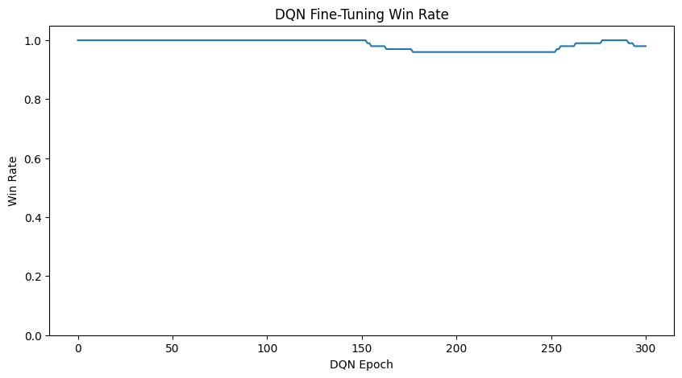

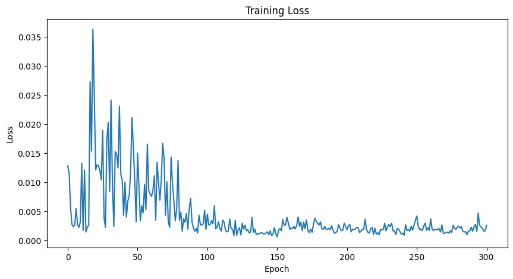

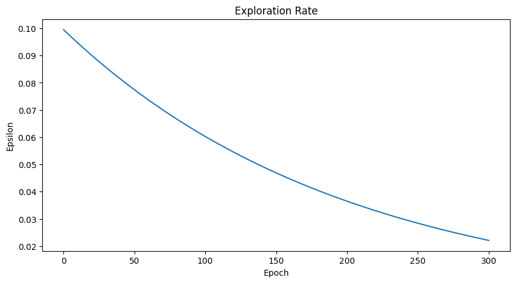

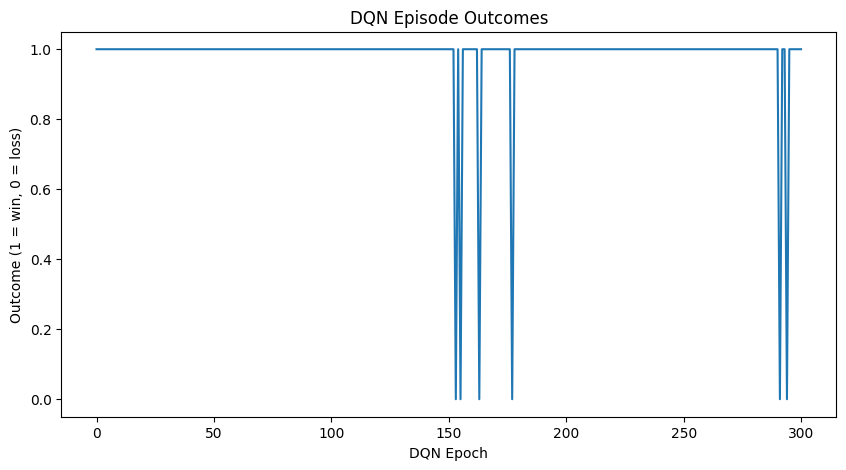

```
<Sequential name=sequential, built=True>
```

```python
model = build_model(maze)
qtrain(model, maze, n_epoch=2000, max_memory=5000, data_size=64, epsilon=0.1, epsilon_decay=0.995, epsilon_min=0.02)
```

**Note:** This cell will check to see if the model passes the completion check. Note: This could take several minutes.

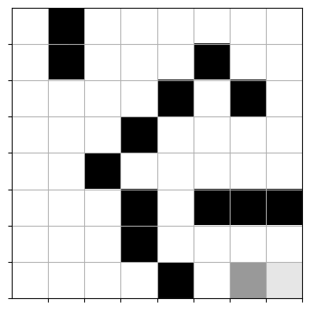

```python
completion_check(model, qmaze)
show(qmaze)
```

This cell will test your model for one game. It will start the pirate at the top-left corner and run **play_game()**. The agent should find a path from the starting position to the target (treasure). The treasure is located in the bottom-right corner.

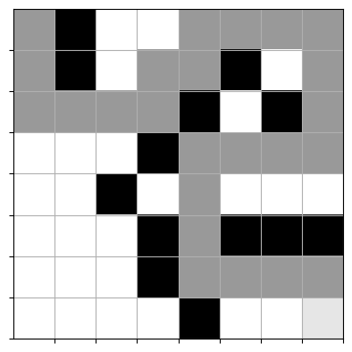

```python
pirate_start = (0, 0)
play_game(model, qmaze, pirate_start)
show(qmaze)
```

## Save and Submit Your Work

**Hint:** To use the markdown block below, double click in the **Type Markdown and LaTeX: 𝛼2** block below, to turn it back to html, Run the cell.

After you have finished creating the code for your notebook, save your work. Make sure that your notebook contains your name in the filename (e.g. Doe_Jane_ProjectTwo.html). Download this file as an .html file clicking on **file** in *Jupyter Notebook*, navigating down to **Download as** and clicking on **.html**. Download a copy of your .html file and submit it to Brightspace.